# Analisi Femminicidi in Italia dal 2012 al 2016

## Motivazioni

- **Perché abbiamo deciso di intraprendere questo progetto?**
  - Vogliamo fornire dati concreti che possano essere utili per sviluppare politiche di prevenzione e intervento più efficaci.
- **Cosa ci ha spinto ad interessarci a questo argomento?**
  - Un interesse personale per la giustizia sociale.

## Domande di Ricerca

- Come sono distribuiti i casi di femminicidio in Italia nel tempo?
- Come vengono trattate nei procedimenti giudiziari?
- Quali sono i luoghi più frequenti?
- Quali sono le modalità più frequenti utilizzate nei femminicidi?
- Relazioni tra Vittime e Assassini

# Descrizione dei Dati

- **Quali dati sono stati usati?**
  - Il dataset comprende le sentenze di femminicidio dal 2012 al 2016.
- **Che tipo di dati contiene?**
  - Anno dell'omicidio, modalità dell'omicidio, luogo dell'omicidio, relazione tra autore e vittima.
- **Chi ha creato il dataset?**
  - Il dataset è stato autoprodotto usando dati del Ministero della Giustizia a cura di Fabio Bartolomeo, Direttore generale di statistica al Ministero della giustizia e referente dell'Italia.
- **Quando è stato creato il dataset?**
  - Il dataset è stato creato fine giugno 2024
- **È disponibile online?**
  - E' disponibile online il file dal quale ho estratto i dati [qui](https://www.istat.it/it/files/2018/04/Analisi-delle-sentenze-di-Femminicidio-Ministero-di-Giustizia.pdf).

## Limiti dei Dati

- **Completezza dei Dati:**
  - I dati disponibili potrebbero non coprire tutti i casi di omicidio e femminicidio in Italia, specialmente quelli non denunciati o non registrati correttamente.
- **Tempistica:**
  - Alcuni dati potrebbero non essere aggiornati o riflettere ritardi nella raccolta e registrazione delle informazioni.
- **Dettagli Insufficienti:**
  - I dataset mancano di dettagli importanti, come informazioni più specifiche sulle motivazioni e le circostanze degli omicidi.

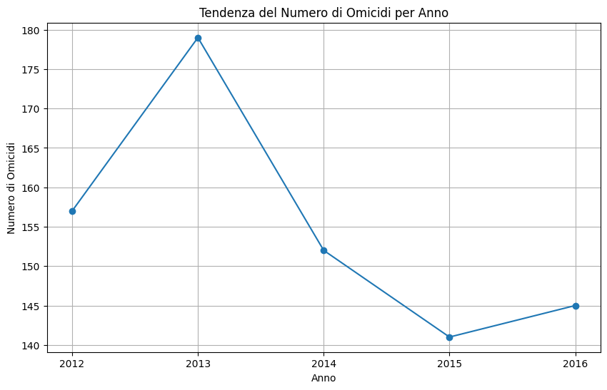

# La variazione percentuale

La variazione percentuale esprime il cambiamento del numero di omicidi rispetto all'anno precedente in termini percentuali.

```
   Anno  Numero di Omicidi  Variazione Percentuale
0  2012                157                    0.00
1  2013                179                   14.01
2  2014                152                  -15.08
3  2015                141                   -7.24
4  2016                145                    2.84
```

## Media annuale

```
La somma di tutti omicidi è: 774
La media nel periodo analizzato è di 154.8 omicidi.
```

# Casi Portati a Giudizio

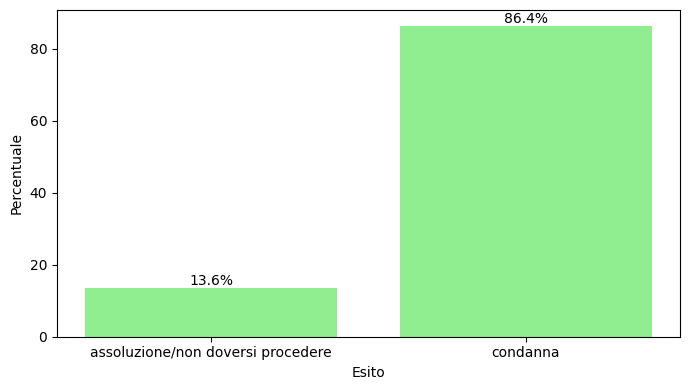

## Dettagli casi Assolti

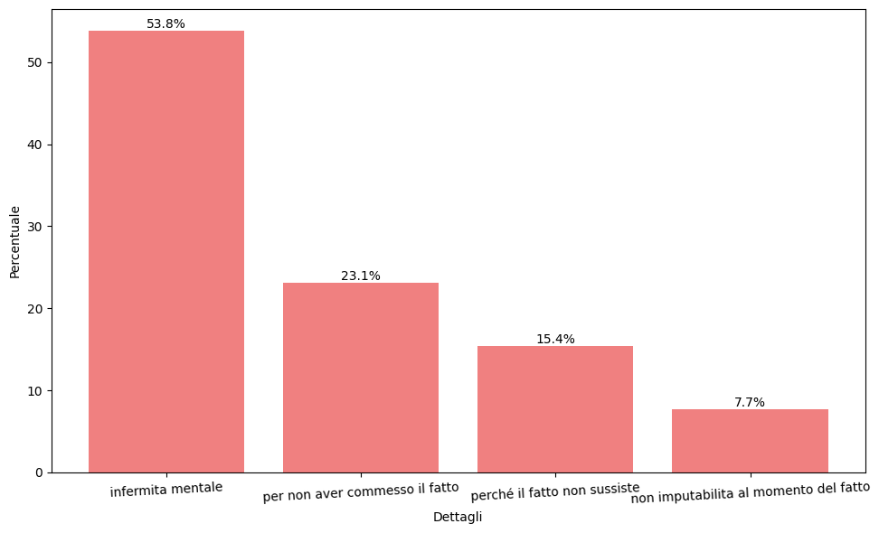

## Dettagli dei casi condannati

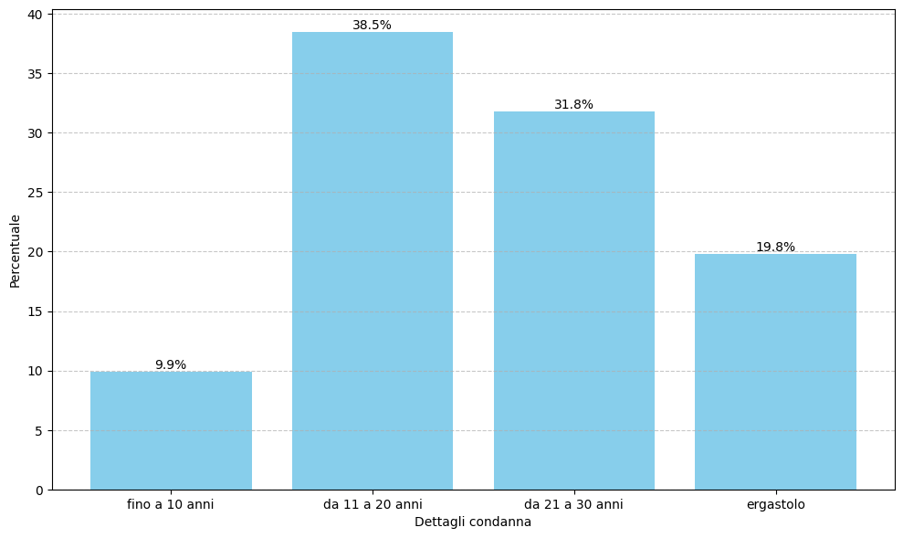

# Luoghi dei Femminicidi

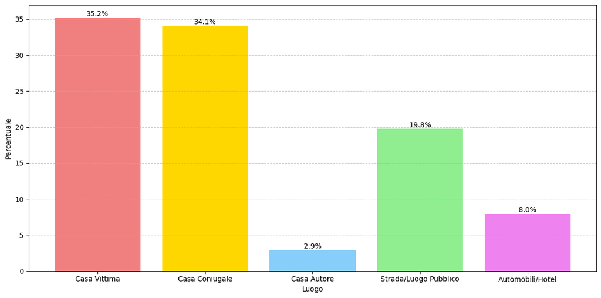

# Modalità dei femminicidi

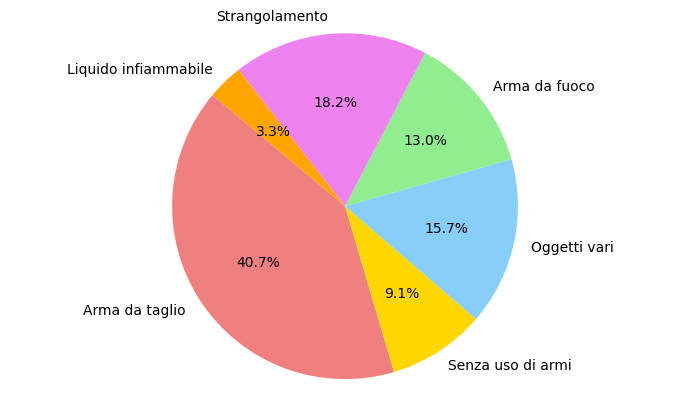

# Relazioni Vittime/Assassini

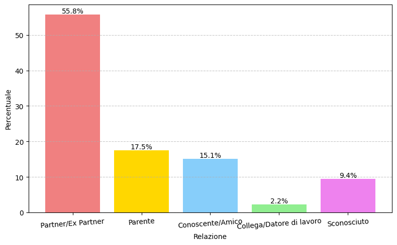

# Conclusioni

## Considerazioni

- Educazione e Sensibilizzazione
- Interventi Preventivi ragionando su una ricerca e raccolta dati approfondita